# Final Project: R Reference

Mandy Klehr

12/16/2021

# R Reference Guide

## Loading Data and Packages

Once you have installed packages into R, you need to load them using one of two functions:

1. library( )
2. require( )

Below I will show how to use library and require to load the *palmerpenguins* data.

```r
library(palmerpenguins)
require(palmerpenguins)
```

Both of these accomplish the same thing and it is just a preference for which you wish to use. I prefer to use require( ). However, library( ) is useful to identify errors in your code, such as if the package you are trying to use is not yet installed, by giving an error on that line of your code. If you use require( ), you’ll receive a warning and the program will continue to run, only to give an error later when you try to use the package that is not installed. This can be helpful and save time and headaches later on if you can easily identify the error early on instead of having to go through all of your code to find the issue.

### here( )

The function here( ) is designed to work with **RProjects** and will use your working directory to import data files. Here is not a base package in R and will initially need to be installed if not already. Once here( ) is installed we can load it using library or require as we did above with the *palmerpenguins* data.

```r
require(here)
```

Next, we want to use here( ) to locate and import the 2021 Ginkgo Data. This can be done using the read.csv( ) function with here( ).

```r
## Locate and read the ginkgo data file saved in the working directory folder
read.csv(here("data", "ginkgo_data_2021.csv"))
```

## Data Structures

### c( )

The function c( ) *combines* or *concatenates* its arguments into a vector (a 1-dimensional data structure consisting of 1 or more elements).

- All of the elements must be of the same type.
- I can’t combine character and numeric types in the same call to c( )

Here are two examples using numeric and character data types:

```r
## Create a vector of numbers:
num_vec  = c(1, 4, 8, 9, 13)

## Create a vector of characters:
char_vec = c("a", "fish", "data", "is", "cool")
```

I can show the contents of a vector by typing the name of the vector, or using the print( ) function.

```r
## Typing the name of the vector into the console prints the contents:
num_vec
```

```
## [1]  1  4  8  9 13
```

```r
## The print() function accomplishes the same task:
print(char_vec)
```

```
## [1] "a"    "fish" "data" "is"   "cool"
```

### matrix( ) and data.frame( )

The functions for matrix( ) and data.frame( ) can be used to store data and they have similar but different uses.

#### matrix ( )

We’ll look at uses for matrix( ) first. Typically, it is for a homogeneous collection of data sets, e.g., all numbers or all characters, arranged in a matrix with a fixed number of rows and columns.

In addition to the values we want to include in the matrix, there are also a few additional items we will need to consider in the function to create our matrix: * nrow - for the number of rows in the matrix * ncol - for the number of columns in the matrix * byrow - to organize the matrix by columns or rows, the default is by column so if we want to organize by rows we will need to add *“byrow = TRUE”*

```r
## Create a matrix with 10 variables, 2 columns, and 5 rows that is organized by row:
matrix(c(1:10), nrow = 5, ncol = 2, byrow = TRUE)
```

```
##      [,1] [,2]
## [1,]    1    2
## [2,]    3    4
## [3,]    5    6
## [4,]    7    8
## [5,]    9   10
```

```r
## Create the same matrix, but organize it by columns. Note that because the default is columns, there is no argument for byrow:
matrix(c(1:10), nrow = 5, ncol = 2)
```

```
##      [,1] [,2]
## [1,]    1    6
## [2,]    2    7
## [3,]    3    8
## [4,]    4    9
## [5,]    5   10
```

You’ll notice that between the two, it will either distribute the values from 1-10 across the columns or across the rows when we use the *“byrow = TRUE”* argument.

#### data.frame( )

Unlike matrix( ), data.frame( ) can be used to store data in tables and can contain both numerical and character data types. We can use it to create data frames or tables in R by hand or use read.csv( ) and here( ) to read and store csv files located in our working directory as data frames.

```r
## Create a data frame with new vectors:

student = c("Shaggy", "Scooby", "Velma", "Fred", "Daphne")
grade_percent= c(70, 25, 100, 82, 91)
grade_char = c("C-", "F", "A+", "B-", "A-")
gpa = c(1.7, 0.0, 4.0, 2.7, 3.7)
dat_gradebook = data.frame(student, grade_percent, grade_char, gpa)

## Print dat_gradebook
dat_gradebook
```

```
##   student grade_percent grade_char gpa
## 1  Shaggy            70         C- 1.7
## 2  Scooby            25          F 0.0
## 3   Velma           100         A+ 4.0
## 4    Fred            82         B- 2.7
## 5  Daphne            91         A- 3.7
```

```r
## Create a data frame with the num_vec and char_vec:

dat_num_char = data.frame(num_vec, char_vec)

## Print dat_num_char
dat_num_char
```

```
##   num_vec char_vec
## 1       1        a
## 2       4     fish
## 3       8     data
## 4       9       is
## 5      13     cool
```

```r
## Create and save the ginkgo data in a data frame that is saved in the R environment with a unique name using read.csv( ) and here( ):

dat_ginkgo = read.csv(here("data", "ginkgo_data_2021.csv"))

##Note that dat_ginkgo is a vary large data frame so I did not print it in this code.
```

### length( )

The length( ) function can be used to get or set the length of a vector or other objects (such as matrices and data frames).

Using the example from the c( ) function we can figure out the length of the *num_vec* and *char_vec* lists:

```r
## Use length to identify how many numbers are in num_vec:

length(num_vec)
```

```
## [1] 5
```

```r
## Use length to identify how many chatacters are in char_vec:

length(char_vec)
```

```
## [1] 5
```

### nrow( ) and ncol ( )

Other than the use of setting the number of rows and columns in a matrix or data frame, we can use nrow( ) and ncol( ) to identify how many rows or columns are in our data frame. This is especially useful if the data frame is very large, or we need to use these values for analyses.

In the example below, I will use the ginkgo data frame:

```r
nrow(dat_ginkgo)
```

```
## [1] 756
```

```r
ncol(dat_ginkgo)
```

```
## [1] 6
```

Now we know in our *dat_ginkgo* data frame, we have 756 rows and 6 columns.

### dim( )

Additionally, we can use dim( ) to get or set the dimensions of a data frame or other object. This may be used instead of nrow( ) and ncol( ) to get the number of rows and columns in a data frame.

In the example below, I will use dim( ) to identify the dimensions of the ginkgo data frame:

```r
dim(dat_ginkgo)
```

```
## [1] 756   6
```

Like using nrow( ) and ncol( ), this gives us the number of rows (756) and number of columns (6). It is also a much simpler step, but as noted above, if we need to use these specific values for an analysis, we would use nrow( ) or ncol( ).

## Subsetting

There are a number of ways we can subset data in a data frame. In general, there are three ways to subset data in R:

1. Using square brackets **[ ]** and double square brackets **[ ]** which can be used to select elements in lists and to select rows, columns, or specific elements in rows and columns in a data frame or matrix.
2. Using the dollar sign **$** to select elements or rows or columns that are named
3. Using the **subset( )** function for conditional or logical subsets

### $

First, we can use **$** to select data in a data frame if rows or columns are named. This example shows how to select the data in the *petiole_length* column in the ginkgo data frame:

```r
dat_ginkgo$petiole_length
```

```
##   [1]  30.00  23.00  20.00  28.00  25.00  55.00  27.00  20.00  50.00  23.00
##  [11]  28.00  26.00  43.00  45.00  42.00  40.00  42.00  40.00  48.00  37.00
##  [21]  50.00  35.00  47.00  23.00  21.00  25.00  41.00  78.00  88.00  38.00
##  [31]  59.00  85.00  42.00  73.00  56.00  76.00  94.00  57.00  30.00  28.00
##  [41]  80.00  58.00  70.00  64.00  43.00  58.00  49.00  35.00  72.00  88.00
##  [51]  63.00  55.00  56.00  54.00  49.00  28.00  57.00  53.00  51.00  80.00
##  [61]  42.00  49.00  49.00  36.00  33.00  46.00  59.00  41.00  58.00  96.00
##  [71]  58.00  45.00  34.00  35.00  59.00  78.00  78.00  41.00  75.00  41.00
##  [81]  30.00  23.00  20.00  28.00  25.00  55.00  27.00  20.00  50.00  23.00
##  [91]  28.00  26.00  43.00  45.00  42.00  40.00  42.00  40.00  48.00  37.00
## [101]  50.00  35.00  47.00  23.00  21.00  25.00  41.00  57.00  40.00  25.00
## [111]  38.00  48.00  48.00  53.00  52.00  52.00  51.00  65.00  48.00  88.00
## [121]  25.00  33.00  68.00  45.00  55.00  51.00  61.00  30.00  37.00  50.00
## [131]  72.00  31.00  54.00  27.00  32.00  59.00  48.00  54.00  93.00  54.00
## [141]  43.00  42.00  14.00  27.00  70.00  58.00  48.00  60.00  52.00  55.00
```

[output cut: 61 more lines]

This returns all of the values for the petiole_length variable and is organized in a matrix-like table.

### [ ]

We can use square brackets **[ ]** to also do some subsetting. When using square brackets to subset a data frame, we want to identify the rows or columns we are selecting in a specific way; the row number will be first followed by a column and the column number ex. [5, 10].

This example subsets the ginkgo data frame by selecting the first row:

```r
## Select the first row of data in the data frame, note use of comma without a column value to select a single row and all of the column data included in that row:

dat_ginkgo[1,]
```

```
##   ï..site_id seeds_present max_width max_depth notch_depth petiole_length
## 1       7719         FALSE        71        40           0             30
```

This is great way to look at all of the variables/values in each of the columns for this one row of data. But what if we wanted to select a specific element in a row and column?

We will use a similar syntax as we used to get one row of data but include a value for column to select a single element, as is shown in this example:

```r
## Select an element in the second row and third column:

dat_ginkgo[2, 3]
```

```
## [1] 64
```

Lastly, we can use square brackets to select a specific column, like we did for selecting a row:

```r
## Select the third column, note that this time we have no value for row to select a single column:

dat_ginkgo[,3]
```

```
##   [1]  71.0  64.0  55.0  62.0  65.0  70.0  63.0  56.0  51.0  57.0  59.0  63.0
##  [13]  70.0  50.0  56.0  46.0  54.0  62.0  56.0  55.0  59.0  60.0  63.0  61.0
##  [25]  58.0  55.0  53.0  81.0  94.0  75.0  82.0  86.0  79.0  93.0  88.0  76.0
##  [37]  71.0  91.0  71.0  82.0  65.0  83.0  73.0 102.0  78.0  88.0  81.0  70.0
##  [49]  80.0  96.0  80.0  82.0  86.0  87.0  89.0  69.0  93.0  98.0  81.0  79.0
##  [61]  82.0  85.0  81.0  59.0  53.0  83.0  80.0  77.0  81.0  76.0  82.0  81.0
##  [73]  77.0  68.0  41.0  70.0  68.0  80.0  89.0  90.0  71.0  64.0  55.0  62.0
##  [85]  65.0  70.0  63.0  56.0  51.0  57.0  59.0  63.0  70.0  50.0  56.0  46.0
##  [97]  54.0  62.0  56.0  55.0  59.0  60.0  63.0  61.0  58.0  55.0  53.0  77.0
## [109]  72.0  57.0  75.0  75.0  75.0  67.0  74.0  71.0  72.0  55.0  77.0  97.0
## [121]  73.0  64.0  69.0  92.0  64.0  68.0  53.0  97.0 100.0  90.0  89.0  59.0
## [133]  97.0  76.0  85.0  90.0  87.0  85.0  80.0  86.0  89.0  84.0  88.0  80.0
## [145] 102.0  94.0  95.0 109.0  84.0  68.0  59.0  74.0  70.0  71.0  69.0  74.0
## [157]  70.0  78.0  87.0  69.0  60.0  72.0  59.0  75.0  81.0  82.0  74.0  72.0
## [169]  79.0  84.0  75.0  72.0  88.0  80.0  90.0  58.0  61.0  95.0  72.0  90.0
```

[output cut: 48 more lines]

### subset( )

The subset( ) function allows for conditional or logical subsetting for vector-like objects, matrices, and data frames.

In this example, I will use subset( ) to create a new dataframe of all of the Adelie penguin data from the palmerpenguins dataset.

```r
## Create a dataframe with ALL of the palmerpenguins data:

penguin_dat = data.frame(penguins)

## Create new dataframe with ALL of the palmerpenguins data, note us of double equal signs to select single species column named Adelie:
dat_adelie = subset(penguin_dat, species == "Adelie")

## Print dat_adelie data frame:
dat_adelie
```

```
##     species    island bill_length_mm bill_depth_mm flipper_length_mm
## 1    Adelie Torgersen           39.1          18.7               181
## 2    Adelie Torgersen           39.5          17.4               186
## 3    Adelie Torgersen           40.3          18.0               195
## 4    Adelie Torgersen             NA            NA                NA
## 5    Adelie Torgersen           36.7          19.3               193
## 6    Adelie Torgersen           39.3          20.6               190
## 7    Adelie Torgersen           38.9          17.8               181
## 8    Adelie Torgersen           39.2          19.6               195
## 9    Adelie Torgersen           34.1          18.1               193
## 10   Adelie Torgersen           42.0          20.2               190
## 11   Adelie Torgersen           37.8          17.1               186
## 12   Adelie Torgersen           37.8          17.3               180
## 13   Adelie Torgersen           41.1          17.6               182
## 14   Adelie Torgersen           38.6          21.2               191
```

[output cut: 291 more lines]

## Numerical Data Exploration

### summary( )

The function summary( ) can be used to produce various summary results, such as the mean and median, of numeric objects (vectors), including those in a data frame, or model fitting functions.

In the example below, I will show how this function works to summarize some data within the ginkgo data frame:

```r
## Create a summary of the petiole.length column:

summary(dat_ginkgo$petiole_length)
```

```
##    Min. 1st Qu.  Median    Mean 3rd Qu.    Max.    NA's
##    8.00   34.00   47.00   48.25   60.00  113.00       4
```

### mean( )

Similar to the summary( ) function, we can use the mean( ) function to identify the arithmetic mean value of a numeric objects in a data frame. It is important to know that if there are **NA** values in the data that we wish to calculate the mean for, we will need to use an argument in the function to remove those. If we do not, the function will return an **NA** as it will not be able to compute the mean with those data. The argument is **na.rm** which has a default of FALSE so it will need to be TRUE to remove NA values.

In the example below, I will use the same *petiole_length* of the ginkgo data frame to demonstrate this, both without na.rm and na.rm = TRUE.

```r
## Calculate mean but do not change na.rm from default of FALSE:

mean(dat_ginkgo$petiole_length)
```

```
## [1] NA
```

```r
## Calculate mean and remove NA values with na.rm = TRUE:

mean(dat_ginkgo$petiole_length, na.rm = TRUE)
```

```
## [1] 48.2515
```

So far so good, our mean value calculated above appears to be the same as the mean value obtained using the summary( ) function.

### sd( )

Lastly, we can calculate the standard deviation (sd) or the measure of the distribution of the variance of our data using the sd( ) function.

Similar to the mean( ) function, we will need to remove **NA** values for R to compute the standard deviation.

```r
sd(dat_ginkgo$petiole_length, na.rm = TRUE)
```

```
## [1] 18.58855
```

This is a fairly high sd and we could imagine that the spread of our values would be fairly wide if they were represented in a graph, which we will explore next (just not with petiole_length)!

## Graphical Data Exploration

### Scatterplot [plot( )]

The function to create a scatterplot of data from a data frame (or otherwise) is plot( ). Plot ( ) has a couple of required arguments in order for data to be plotted. These include:

- x = the predictor variable plotted on the x-axis
- y = the response variable plotted on the y-axis
- xlim and ylim = not required but these can be adjusted if for some reason the data is plotted beyond the limits of the axes. it is usually plotted as a range, e.g. c(0,100)

Plot( ) also has several arguments that can be changed to customize how the plotted data is presented. Some that we will explore include:

- col - change the color of plotted data, can be a number that is specific to a color or a name e.g. “blue” and default is black
- pch - change the point symbol or shape, list of different numbered symbols is available online and default is hollow circle (pch=1)
- cex - amount that plot text and symbols are scaled relative to a default of 1, can be applied to axis, labels, main title, and subtitles
- main - add a main title to the plot, use "" with characters
- xlab - add a label to the x-axis, use "" with characters
- ylab - add a label to the y-axis, use "" with characters

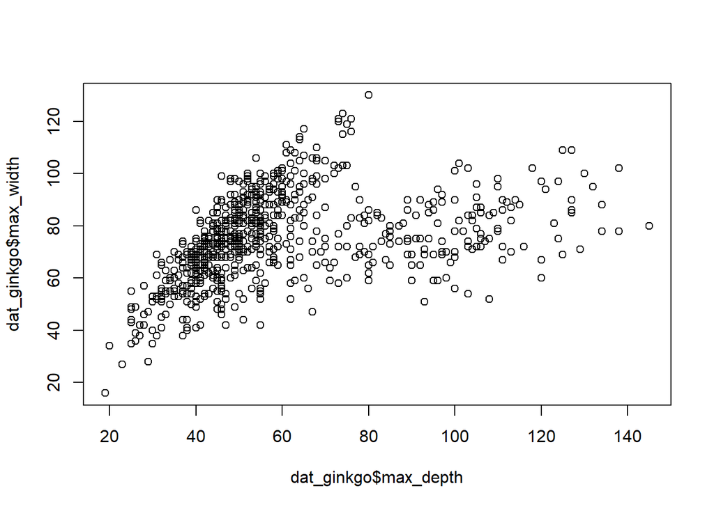

```r
## First: a simple scatterplot of the data:

plot(x = dat_ginkgo$max_depth, y = dat_ginkgo$max_width)
```

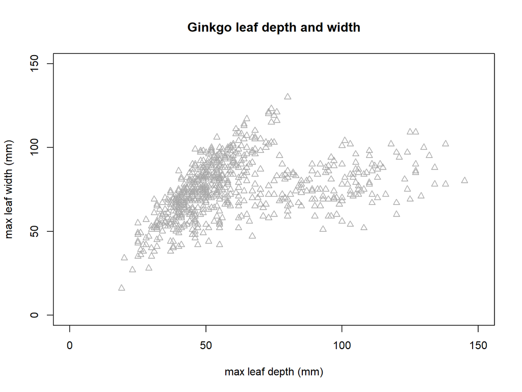

```r
## Second: a customized scatterplot using the arguments described above:

plot(x = dat_ginkgo$max_depth, y = dat_ginkgo$max_width,
     main = "Ginkgo leaf depth and width",
     xlab = "max leaf depth (mm)",
     ylab = "max leaf width (mm)",
     col = "dark gray",
     pch = 2,
     xlim = c(0, 150),
     ylim = c(0, 150))
```